# Assignment 1

Travis Rutledge, Dylan Cheung, Dulitha Perera, Chris Liolios

2024-09-24

# Task 1

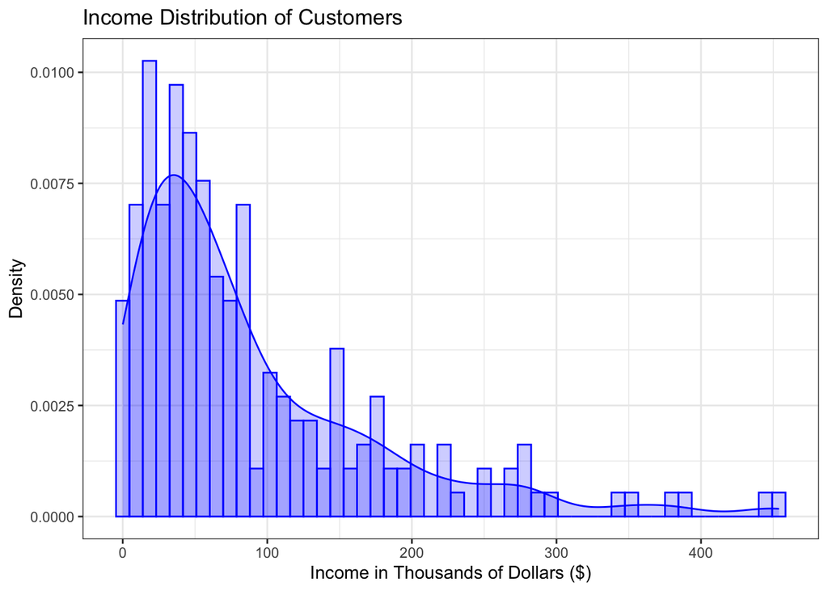

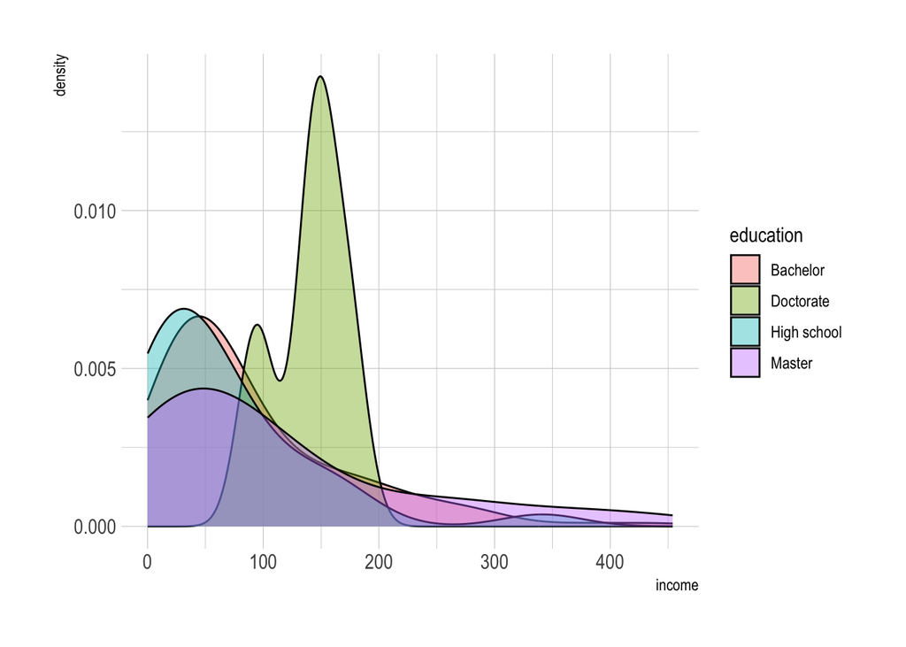

The manager wants to understand the distribution of her customers’ incomes. She would like some appropriate descriptive and visual summaries of the data. In addition, she would like a fitted model, which her team will use to help inform their product design and marketing strategy. Required analyses and components: • One or more appropriate plots to visualise the data. • Some appropriate descriptive statistics. • Explore fitting various models. Include at least the following distributions: normal, exponential, gamma. • Your exploration should include using appropriate QQ plots and calculating maximum likelihood estimates.

• Explanations of what analyses you are carrying out. • The results of your analyses (including plots, numerical results, and conclusions). • Enough details about your analysis choices and assumptions so that someone with technical knowledge (e.g., another statistician) would understand them and could replicate your work. • A summary of your methods and findings, and any key assumptions, in a form that would be under- standable to the manager (e.g., using non-technical language).